# Reconstrução de viagens e pontualidade (IPP) — Olho Vivo

Linhas 7267-10 (circular) e 701A-10 · setembro de 2026

Data de Publicação

16 de novembro de 2026

## Resumo executivo

- **Observado** — 902.725 posições GPS de 238 prefixos, de 31/08 23h50 a 30/09 23h59 (horário local). A coleta é estável: intervalo mediano de 44–45 s e menos de 0,3% de intervalos acima de 5 min.
- **Reconstruído (inferência)** — em setembro, a **7267-10** teve 1.608 voltas completas (confirmadas ou prováveis) e a **701A-10** teve 2.792 viagens completas (as duas direções somadas). Nos dias úteis, isso dá 48–67 voltas/dia na 7267 (mediana de 59; 69 programadas) e 93–114 viagens/dia na 701A (mediana de 105; 126 programadas).
- **IPP (inferência, sujeita à premissa da programação)** — IPP de **56.6%** na 7267-10 e de **36.6%** na 701A-10, contra a referência de 97% da SPTrans. São 1.820 e 3.322 saídas programadas válidas, respectivamente, incluindo domingos e o feriado de 7/9 (tabela de domingo da coleta de 04/11/2026). Saídas *possivelmente não realizadas*: 91 (5.0%) e 128 (3.9%).
- **Ressalva principal** — a programação usada é a raspagem de **25/10/2026** (dias úteis e sábados) e a coleta de **04/11/2026** (domingos e 7/9), aplicadas a setembro. Se os horários mudaram entre setembro e outubro, os atrasos, antecipações e saídas “não realizadas” ficam inflados. Na 7267, o IPP cai de ~77% (1–11/9) para ~45% (a partir de 12/9), o que é compatível com uma mudança de programação **ou** de operação; não há como distinguir sem a tabela vigente em setembro.

## Dados e qualidade

Inventário (hash MD5 dos brutos)

| arquivo | tamanho_mb | registros | veiculos | ta_min_utc | ta_max_utc | md5 |
| --- | --- | --- | --- | --- | --- | --- |
| linha_7267_10_setembro.parquet | 2.16 | 250075 | 81 | 2026-09-01 02:51:09 | 2026-10-01 02:59:23 | d0d4b2bbbb24615877b4ba1b5171a535 |
| linha_701A_10_setembro.parquet | 5.33 | 652650 | 157 | 2026-09-01 02:50:35 | 2026-10-01 02:59:19 | 42fbcd06e14f1460bc884cc04ef85775 |

Indicadores de qualidade por linha (contagens de registros, exceto os intervalos dt_*)

| indicador | 701A-10 | 7267-10 |
| --- | --- | --- |
| dt_mediana_s | 45 | 44 |
| dt_p10_s | 19 | 18 |
| dt_p90_s | 45 | 45 |
| dt_p99_s | 67 | 62 |
| qc_coord_invalida | 0 | 0 |
| qc_coord_travada | 79250 | 30550 |
| qc_dup_exato | 1689 | 350 |
| qc_dup_instante | 419 | 926 |
| qc_lacuna_5min | 1440 | 176 |
| qc_linha_ausente | 0 | 0 |
| qc_prefixo_ausente | 0 | 0 |
| qc_salto_espacial | 3545 | 626 |
| qc_troca_sl | 3950 | 4017 |
| qc_ts_invalido | 0 | 0 |
| registros_total | 652650 | 250075 |
| registros_validos | 650542 | 248799 |

**Achados que orientaram o método:**

1. **As posições do /Posicao já chegam “encaixadas” no itinerário.** A 701A tem só 1.707 coordenadas distintas em 650 mil registros (~1 a cada 30 m de percurso), e cada coordenada pertence quase sempre a um único `sl`. A distância GPS–traçado é praticamente nula, e o erro relevante não é o ruído do GPS: é **em qual itinerário (sentido) o sistema encaixou o ponto**.
2. **Saltos sintéticos entre terminais.** Quando o `sl` é trocado, ou após um período sem sinal, o ônibus pode “saltar” por 1–5 registros para o terminal do sentido marcado (ex.: Vila Madalena → Edu Chaves → Vila Madalena em 2 min). Esses pontos são descartados como *outliers* no map-matching (`quebra = 4`), sem excluir o registro da base normalizada.
3. **A marcação `sl` é um indicador fraco do sentido real.** O sentido inferido pela posição e pela ordem temporal discorda do `sl` em 11,8% dos pontos com `sl = 2` na 701A. Na circular 7267, o `sl` troca de 1 para 2 em torno do km 8,1 (Pça. Ramos), mas 10% das trocas acontecem já no km 0:

Marcação sl × sentido inferido (701A) e posição das trocas de sl na circular (7267)

| sl | sentido_inferido | N | linha | pct | troca | n | pos_km_p10 | pos_km_mediana | pos_km_p90 |
| --- | --- | --- | --- | --- | --- | --- | --- | --- | --- |
| 1 | 0 | 286686 | 701A-10 | 99.73 |  | NA | NA | NA | NA |
| 1 | 1 | 782 | 701A-10 | 0.27 |  | NA | NA | NA | NA |
| 2 | 0 | 42301 | 701A-10 | 11.76 |  | NA | NA | NA | NA |
| 2 | 1 | 317523 | 701A-10 | 88.24 |  | NA | NA | NA | NA |
| NA | NA | NA | 7267-10 | NA | 2->1 | 2025 | 0.0091138 | 0.0091138 | 0.0266591 |
| NA | NA | NA | 7267-10 | NA | 1->2 | 1878 | 0.0000000 | 8.0977529 | 8.1211594 |

Versão do GTFS escolhida por linha (fração dos pontos GPS a até 50 m do traçado)

| line_id | gtfs_versao | frac_pontos_ate_50m | L_km | circular | escolhida |
| --- | --- | --- | --- | --- | --- |
| 701A-10 | 20261104 | 1.0000 | 53.660 | FALSE | TRUE |
| 701A-10 | 20260226 | 1.0000 | 53.678 | FALSE | FALSE |
| 7267-10 | 20261104 | 1.0000 | 16.511 | TRUE | TRUE |
| 7267-10 | 20260226 | 0.9544 | 14.614 | TRUE | FALSE |

## Método

**Ciclo da linha.** Cada linha vira uma polilinha **fechada** em metros (UTM 23S). Nas linhas com dois sentidos, ela é o shape do sentido 0 (TP→TS) seguido do shape do sentido 1 (TS→TP); nas circulares, é o próprio shape, que começa e termina no TP. O ônibus só avança no ciclo. A troca de sentido é inferida quando ele **cruza** a posição do TS (ou do TP), e não pela marcação `sl`. Para cada linha, a versão do GTFS é escolhida pelo melhor ajuste aos pontos GPS: a 20260226 tem calendário até 01/09/2026 e traçado diferente na 7267.

**Map-matching (HMM/Viterbi, C++).** Para cada posição, os candidatos são todos os mínimos locais de distância ao ciclo num raio de 120 m; uma via usada nos dois sentidos gera dois candidatos. O Viterbi escolhe a sequência que avança (recuo tolerado de 60 m), respeita a velocidade máxima de 70 km/h e tem a distância percorrida no ciclo mais próxima da distância em linha reta. A cadeia é quebrada quando o veículo **para de transmitir** por mais de 30 min. Ficar fora do traçado mas transmitindo (dentro do terminal, por exemplo) não quebra a cadeia. O progresso “desenrolado” `u` conta as voltas.

**Viagens.** Uma viagem candidata é a passagem de uma cadeia pelo intervalo de progresso do sentido *k* na volta *n*. A **partida** é o instante (interpolado) em que se cruza TP/TS + 50 m. Quando o par de pontos que cerca esse limiar tem lacuna, mas o ponto seguinte está a até 500 m, a partida é estimada pela velocidade de manobra (15 km/h). A **chegada** é o cruzamento do fim do sentido − 150 m. A **cobertura** é a fração do percurso coberta por pares de pontos com intervalo ≤ 300 s, o critério de “sem transmissão” do IDTA.

| Classe | Critério |
| --- | --- |
| `viagem_confirmada` | partida e chegada evidenciadas, cobertura ≥ 90%, lacuna máxima ≤ 10 min, velocidade média entre 4 e 45 km/h |
| `viagem_provavel` | partida e chegada evidenciadas, cobertura ≥ 70% |
| `trajetoria_parcial` | ≥ 25% do percurso observado |
| `observacao_inconclusiva` | demais casos (≥ 1 km observado) |

Na classificação de veículo-dia também aparecem `movimento_sem_itinerario` e `sem_evidencia_de_operacao` (arquivo `veiculos_dia.csv`).

**Passagens por ponto.** Para cada viagem e cada parada do sentido, o horário é obtido por interpolação linear do progresso entre as duas posições que cercam a parada. As paradas são projetadas no traçado respeitando a ordem de `stop_sequence`, o que é necessário nos laços em que a linha passa duas vezes pela mesma via (paradas 5–7 e 41–43 da 7267). A passagem é marcada como `interpolado_sobre_lacuna` quando o par de pontos tem intervalo acima de 300 s.

**Auditoria (IPP).** As saídas programadas são associadas às partidas observadas por **alinhamento ordenado global** (programação dinâmica), por linha × sentido × dia de serviço. Uma viagem justifica no máximo uma saída, e uma saída “pulada” fica sem par em vez de deslocar as seguintes. A janela de associação vai de −15 a +40 min. Tolerância de pontualidade: **±3 min** (IQT.GSO.002.03).

| Status da saída | Regra |
| --- | --- |
| `realizada_no_horario` | associada, \|dif\| ≤ 3 min **e** viagem confirmada ou provável |
| `realizada_com_atraso` / `realizada_antecipadamente` | associada, dif > +3 min / < −3 min, viagem completa |
| `partida_sem_viagem_completa` | houve partida no terminal, mas o percurso não foi comprovado |
| `possivelmente_nao_realizada` | sem partida compatível, com GPS da linha em ≥ 50% dos minutos da janela [−20, +60] min |
| `inconclusiva` | sem partida e sem dados suficientes, **ou** com algum ônibus em serviço sem transmitir no horário |
| `programacao_invalida` / `fora_do_periodo_coletado` | fora do denominador |

IPP = `realizada_no_horario` / saídas válidas × 100. Como o usuário pediu, a partida só conta se o ônibus **cumpriu a viagem**. Por isso este IPP é mais exigente que o da SPTrans, que conta apenas partidas pontuais.

## Resultados — reconstrução

Viagens candidatas por classe (setembro)

| line_id | direction_id | observacao_inconclusiva | trajetoria_parcial | viagem_confirmada | viagem_provavel |
| --- | --- | --- | --- | --- | --- |
| 701A-10 | 0 | 70 | 131 | 1257 | 130 |
| 701A-10 | 1 | 55 | 113 | 1251 | 154 |
| 7267-10 | 0 | 53 | 37 | 1590 | 18 |

Viagens confirmadas: duração e velocidade

| line_id | direction_id | viagens | duracao_mediana_min | p10 | p90 | vel_media_kmh | km |
| --- | --- | --- | --- | --- | --- | --- | --- |
| 7267-10 | 0 | 1590 | 67 | 50 | 82 | 14.8 | 16.5 |
| 701A-10 | 0 | 1257 | 124 | 80 | 169 | 12.8 | 26.5 |
| 701A-10 | 1 | 1251 | 114 | 79 | 156 | 14.3 | 27.1 |

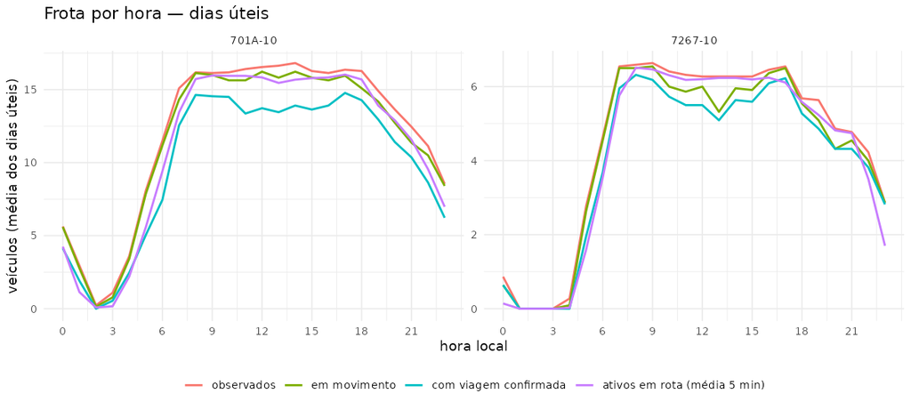

## Resultados — auditoria das saídas

| line_id | programadas_total | programadas_validas | no_horario | com_atraso | antecipadas | partida_sem_viagem_completa | possivelmente_nao_realizadas | inconclusivas | IPP_pct | realizadas_pct | nao_realizadas_pct |
| --- | --- | --- | --- | --- | --- | --- | --- | --- | --- | --- | --- |
| 701A-10 | 3324 | 3322 | 1215 | 798 | 559 | 103 | 128 | 486 | 36.57 | 77.42 | 3.85 |
| 7267-10 | 1820 | 1820 | 1030 | 367 | 169 | 13 | 91 | 145 | 56.59 | 86.04 | 5.00 |

Por sentido

| line_id | direction_id | programadas_validas | no_horario | com_atraso | antecipadas | possivelmente_nao_realizadas | IPP_pct |
| --- | --- | --- | --- | --- | --- | --- | --- |
| 701A-10 | 0 | 1662 | 576 | 376 | 289 | 63 | 34.66 |
| 701A-10 | 1 | 1660 | 639 | 422 | 270 | 65 | 38.49 |
| 7267-10 | 0 | 1820 | 1030 | 367 | 169 | 91 | 56.59 |

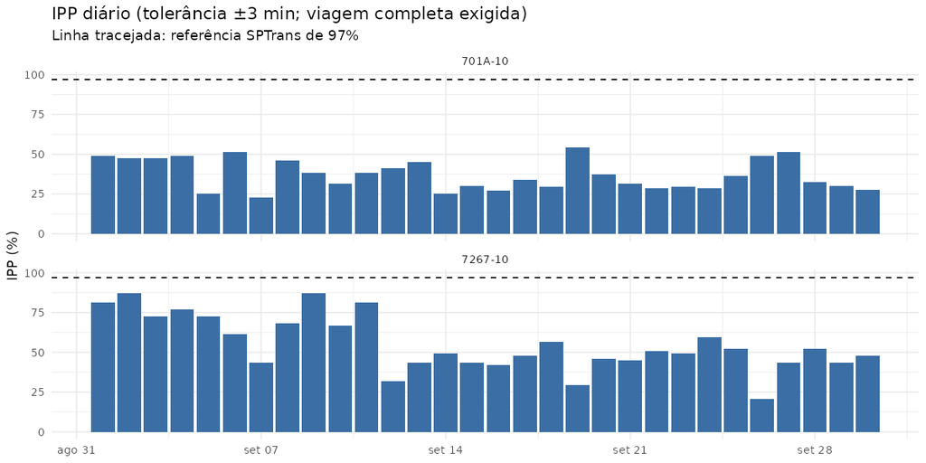

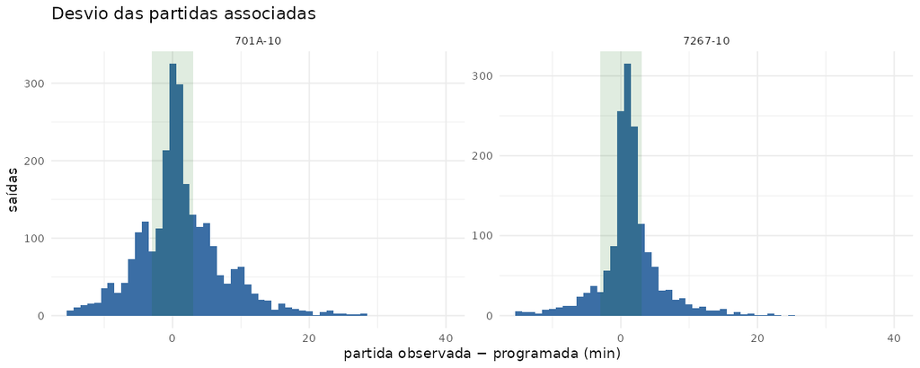

IPP por hora da saída programada (dias úteis)

| hora_prog | 701A-10 | 7267-10 |
| --- | --- | --- |
| 0 | 61.90 | NA |
| 4 | 42.86 | NA |
| 5 | 31.29 | 83.33 |
| 6 | 44.05 | 72.62 |
| 7 | 39.88 | 51.59 |
| 8 | 36.73 | 52.38 |
| 9 | 29.25 | 51.43 |
| 10 | 50.00 | 69.84 |
| 11 | 31.43 | 58.73 |
| 12 | 25.85 | 51.19 |
| 13 | 54.76 | 58.73 |
| 14 | 47.62 | 74.29 |
| 15 | 42.18 | 53.57 |
| 16 | 13.61 | 70.48 |
| 17 | 27.21 | 52.38 |
| 18 | 23.02 | 49.21 |
| 19 | 23.02 | 44.05 |
| 20 | 20.00 | 55.56 |
| 21 | 25.40 | 74.60 |
| 22 | 45.24 | 64.29 |
| 23 | 48.81 | 95.24 |

## Sensibilidade

| line_id | parametro | valor | central | viagens_confirmadas | viagens_provaveis | trajetorias_parciais | IPP_pct | realizadas_pct | possivelmente_nao_realizadas |
| --- | --- | --- | --- | --- | --- | --- | --- | --- | --- |
| 701A-10 | raio_candidato_m | 80.00 | FALSE | 2509 | 283 | 254 | 36.58 | 77.35 | 120 |
| 701A-10 | raio_candidato_m | 120.00 | TRUE | 2510 | 284 | 250 | 36.58 | 77.41 | 120 |
| 701A-10 | raio_candidato_m | 200.00 | FALSE | 2517 | 286 | 243 | 36.82 | 77.68 | 119 |
| 701A-10 | lacuna_interp_s | 180.00 | FALSE | 2490 | 293 | 261 | 36.40 | 77.14 | 120 |
| 701A-10 | lacuna_interp_s | 300.00 | TRUE | 2510 | 284 | 250 | 36.58 | 77.41 | 120 |
| 701A-10 | lacuna_interp_s | 600.00 | FALSE | 2608 | 201 | 235 | 36.76 | 77.80 | 120 |
| 701A-10 | cobertura_confirmada | 0.80 | FALSE | 2599 | 195 | 250 | 36.58 | 77.41 | 120 |
| 701A-10 | cobertura_confirmada | 0.90 | TRUE | 2510 | 284 | 250 | 36.58 | 77.41 | 120 |
| 701A-10 | cobertura_confirmada | 0.95 | FALSE | 2430 | 364 | 250 | 36.58 | 77.41 | 120 |
| 701A-10 | tolerancia_ipp_min | 2.00 | FALSE | 2510 | 284 | 250 | 29.87 | 77.41 | 120 |
| 701A-10 | tolerancia_ipp_min | 3.00 | TRUE | 2510 | 284 | 250 | 36.58 | 77.41 | 120 |
| 701A-10 | tolerancia_ipp_min | 5.00 | FALSE | 2510 | 284 | 250 | 50.90 | 77.41 | 120 |
| 7267-10 | raio_candidato_m | 80.00 | FALSE | 1582 | 17 | 47 | 56.10 | 85.55 | 99 |
| 7267-10 | raio_candidato_m | 120.00 | TRUE | 1590 | 18 | 37 | 56.59 | 86.04 | 102 |
| 7267-10 | raio_candidato_m | 200.00 | FALSE | 1579 | 17 | 50 | 56.04 | 85.44 | 112 |
| 7267-10 | lacuna_interp_s | 180.00 | FALSE | 1587 | 21 | 37 | 56.59 | 86.04 | 102 |
| 7267-10 | lacuna_interp_s | 300.00 | TRUE | 1590 | 18 | 37 | 56.59 | 86.04 | 102 |
| 7267-10 | lacuna_interp_s | 600.00 | FALSE | 1597 | 11 | 37 | 56.59 | 86.04 | 102 |
| 7267-10 | cobertura_confirmada | 0.80 | FALSE | 1597 | 11 | 37 | 56.59 | 86.04 | 102 |
| 7267-10 | cobertura_confirmada | 0.90 | TRUE | 1590 | 18 | 37 | 56.59 | 86.04 | 102 |
| 7267-10 | cobertura_confirmada | 0.95 | FALSE | 1589 | 19 | 37 | 56.59 | 86.04 | 102 |
| 7267-10 | tolerancia_ipp_min | 2.00 | FALSE | 1590 | 18 | 37 | 44.95 | 86.04 | 102 |
| 7267-10 | tolerancia_ipp_min | 3.00 | TRUE | 1590 | 18 | 37 | 56.59 | 86.04 | 102 |
| 7267-10 | tolerancia_ipp_min | 5.00 | FALSE | 1590 | 18 | 37 | 68.96 | 86.04 | 102 |

A reconstrução é estável dentro das faixas testadas: o raio de 80 a 200 m, a lacuna de 180 a 600 s e o limiar de cobertura de 80 a 95% mudam as viagens confirmadas em menos de 4%. O IPP depende quase só da tolerância de pontualidade. A contagem de saídas “não realizadas” fica praticamente inalterada.

## Limitações e recomendações

- **Programação.** Na raspagem de 25/10/2026 (navegador) a tabela de domingo é cópia da de dia útil e é descartada; domingos e 7/9 usam a coleta de 04/11/2026, feita pela API da SPTrans (`coleta_horarios_programados/`), cuja tabela D é correta. Para cada data, linha e sentido, o pipeline usa a coleta válida mais recente anterior a ela ou, na falta, a mais próxima posterior. Novas coletas são lidas automaticamente.
- **Partida observada ≠ partida do SIM.** O instante adotado é o cruzamento do TP + 50 m nas posições já encaixadas pelo Olho Vivo. A resolução é de ~45 s; a regra pode diferir da regra oficial, que usa pontos notáveis.
- **Sem validação independente.** Não há registros oficiais de partidas para medir precisão e sensibilidade. Recomenda-se conferir em mapa uma amostra estratificada, com o `trip_id` de `auditoria_saidas.parquet` e as posições de `posicoes_normalizadas`.
- **Ausência de GPS não é prova de descumprimento.** Saídas que caem em lacunas de transmissão de ônibus em serviço são classificadas como `inconclusiva`.
- **Escala.** A unidade de processamento é a linha, em paralelo. O map-matching leva ~4 s por linha-mês nas linhas testadas, e o pipeline completo (incluindo a sensibilidade) levou ~1,4 min. Com a sensibilidade desligada (`cfg$rodar_sensibilidade = FALSE`), o custo por linha-mês fica em ~15–40 s, dominado pela leitura e pelo QC.

## Verificações automáticas

| verificacao | resultado | detalhe |
| --- | --- | --- |
| viagens: inicio <= fim | OK | 0 violações |
| viagens: duracao coerente com timestamps | OK |  |
| viagens: distancias nao negativas | OK |  |
| viagens: trip_id unico | OK |  |
| viagens: parciais nao contadas como completas | OK |  |
| auditoria: scheduled_trip_id unico | OK |  |
| auditoria: uma classificacao por saida | OK |  |
| auditoria: viagem associada a no maximo uma saida | OK | 0 duplicadas |
| auditoria: associacoes apenas em programacao valida | OK |  |
| auditoria: percentuais entre 0 e 100 | OK |  |
| auditoria: soma das categorias == total programado | OK |  |
| registros: inventario == soma por linha | OK | inventario 902725, linhas 902725 |

## Reprodução

```bash
cd projeto_onibus
Rscript run_pipeline.R
quarto render relatorios/relatorio.qmd
```

Versões

| pacote | versao |
| --- | --- |
| R | R version 4.5.3 (2026-03-11) |
| data.table | 1.17.0 |
| arrow | 20.0.0 |
| sf | 1.1.0 |
| lubridate | 1.9.4 |
| ggplot2 | 3.5.2 |
| Rcpp | 1.0.14 |
| dplyr | 1.1.4 |

Parâmetros desta execução

| parametro | valor |
| --- | --- |
| algorithm_version | mm-ciclo-0.1.0 |
| audit_rule_version | ipp-0.2.0 |
| entrada.posicoes | /mnt/fern/Dados/gitlab/monitoramento-onibus/x_dados/linha_7267_10_setembro.parquet, /mnt/fern/Dados/gitlab/monitoramento-onibus/x_dados/linha_701A_10_setembro.parquet |
| entrada.gtfs_dirs | /mnt/fern/Dados/gitlab/monitoramento-onibus/x_dados/gtfs/20261104, /mnt/fern/Dados/gitlab/monitoramento-onibus/x_dados/gtfs/20260226 |
| entrada.coletas_api_dir | /mnt/fern/Dados/gitlab/monitoramento-onibus/x_dados/linhas_collect/api |
| entrada.coletas_api_datas | NULL |
| entrada.raspagens_dir | /mnt/fern/Dados/gitlab/monitoramento-onibus/x_dados/linhas_collect |
| entrada.raspagens_pastas | 2026-10-25 |
| saida_dir | /mnt/fern/Dados/gitlab/monitoramento-onibus/projeto_onibus/dados/processados |
| relatorio_dir | /mnt/fern/Dados/gitlab/monitoramento-onibus/projeto_onibus/relatorios |
| linhas | NULL |
| n_cores | 2 |
| rodar_sensibilidade | TRUE |
| gravar_arquivos_unicos | TRUE |
| tz_local | America/Sao_Paulo |
| hora_corte_dia | 3 |
| bbox_sp | -47.10, -46.30, -24.05, -23.30 |
| crs_metrico | 31983 |
| mm.raio_candidato_m | 120 |
| mm.fundir_candidatos_m | 40 |
| mm.max_candidatos | 6 |
| mm.sigma_gps_m | 25 |
| mm.beta_m | 80 |
| mm.vmax_ms | 19.44444 |
| mm.folga_m | 150 |
| mm.recuo_tol_m | 60 |
| mm.lacuna_quebra_s | 1800 |
| mm.outlier_lookahead | 6 |
| mm.penal_sl | 0 |
| viagem.lacuna_interp_s | 300 |
| viagem.lacuna_evento_s | 180 |
| viagem.offset_partida_m | 50 |
| viagem.offset_chegada_m | 150 |
| viagem.janela_terminal_m | 500 |
| viagem.vel_ref_terminal_ms | 4.166667 |
| viagem.sobreposicao_min_m | 1000 |
| viagem.cobertura_confirmada | 0.9 |
| viagem.cobertura_provavel | 0.7 |
| viagem.cobertura_parcial | 0.25 |
| viagem.lacuna_max_confirmada_s | 600 |
| viagem.vel_media_min_kmh | 4 |
| viagem.vel_media_max_kmh | 45 |
| passagem.lacuna_max_s | 300 |
| frota.lacuna_min_s | 600 |
| frota.lacuna_max_h | 4 |
| frota.q_duracao | 0.25 |
| frota.folga_min | 10 |
| frota.tol_pos_m | 300 |
| ipp.tolerancia_min | 3 |
| ipp.janela_antecipacao_min | 15 |
| ipp.janela_atraso_min | 40 |
| ipp.custo_nao_assoc_prog | 15 |
| ipp.custo_nao_assoc_obs | 15 |
| ipp.janela_detect_antes_min | 20 |
| ipp.janela_detect_depois_min | 60 |
| ipp.lacuna_veiculo_s | 600 |
| ipp.janela_veiculo_sumiu_h | 4 |
| ipp.parcial_espuria_max | 0.15 |
| ipp.quase_completa_min | 0.95 |
| ipp.quase_completa_cob_min | 0.7 |
| ipp.tolerancia_ampliada_min | 4 |
| ipp.feriados | 2026-09-07, 2026-10-12, 2026-11-02, 2026-11-15, 2026-11-20, 2026-12-25 |
| ipp.tipos_dia_invalidos |  |
| ipp.detectar_D_igual_U | TRUE |
| sensibilidade.raio_candidato_m | 80, 120, 200 |
| sensibilidade.lacuna_interp_s | 180, 300, 600 |
| sensibilidade.cobertura_confirmada | 0.80, 0.90, 0.95 |
| sensibilidade.tolerancia_ipp_min | 2, 3, 5 |

## Trechos dos scripts executados

**código**

```r
############################################################
# 04_viagens.R — segmentação das cadeias em viagens e classificação
#
# Uma viagem candidata é a passagem de uma cadeia pelo intervalo de
# progresso [nL + a_k, nL + b_k] do sentido k na volta n. Os instantes
# são obtidos por interpolação linear do progresso monotônico (u_mono)
# entre posições consecutivas; nenhum horário programado é usado aqui.
############################################################

# Prepara índice global monotônico: chave = chain * BIG + u_mono
.BIG <- 1e9

indexar_obs <- function(v, p = cfg$viagem) {
  o <- v[(na_rota), .(vehicle_id, chain, tnum, u = u_mono, direction_sl, vel_kmh, dist_m, d_rota, x, y)]
  setorder(o, chain, tnum)
  o[, key := chain * .BIG + u]
  o[, `:=`(prox_mesma = c(chain[-1] == chain[-.N], FALSE))]
  o[, dt_prox := fifelse(prox_mesma, shift(tnum, -1) - tnum, NA_real_)]
  o[, du_prox := fifelse(prox_mesma, shift(u, -1) - u, 0)]
  o[, ok_prox := prox_mesma & dt_prox <= p$lacuna_interp_s]
  o[, cob_cum := cumsum(c(0, (du_prox * ok_prox)[-.N]))]   # cobertura acumulada até o ponto
  o[]
}

# Instante (interpolado) em que a cadeia cruza o progresso `thr`
cruzamento <- function(o, chain, thr) {
  k <- chain * .BIG + thr
  i <- findInterval(k, o$key)
  ok <- i >= 1 & i < nrow(o)
  ok[ok] <- o$chain[i[ok]] == chain[ok] & o$prox_mesma[i[ok]] & o$u[i[ok] + 1] > thr[ok]
  t <- dtp <- rep(NA_real_, length(thr))
  j <- i[ok]
  f <- (thr[ok] - o$u[j]) / (o$u[j + 1] - o$u[j])
  t[ok] <- o$tnum[j] + f * (o$tnum[j + 1] - o$tnum[j])
  dtp[ok] <- o$dt_prox[j]
  list(t = t, dt_par = dtp, i = ifelse(ok, i, NA_integer_))
}

# Evento de partida/chegada no limiar `thr` (ver cfg$viagem). Devolve o
# instante estimado e o tipo de evidência.
evento_terminal <- function(o, chain, thr, ch_ini, ch_fim, tipo, p = cfg$viagem) {
  n <- length(thr)
  i <- findInterval(chain * .BIG + thr, o$key)
  t <- rep(NA_real_, n); dtp <- rep(NA_real_, n); ev <- rep("nao_observado", n)
  vref <- p$vel_ref_terminal_ms; jan <- p$janela_terminal_m
  dentro <- i >= ch_ini & i < ch_fim
  antes <- i < ch_ini
  depois <- i >= ch_fim
  # par (j, j+1) que contém o limiar
  j <- i[dentro]
  if (length(j)) {
    u0 <- o$u[j]; u1 <- o$u[j + 1]; t0 <- o$tnum[j]; t1 <- o$tnum[j + 1]; th <- thr[dentro]
    ti <- t0 + (th - u0) / (u1 - u0) * (t1 - t0)
    d <- t1 - t0
    obs <- d <= p$lacuna_evento_s
    if (tipo == "partida") {
      perto <- !obs & (u1 - th) <= jan
      te <- pmax(t0, t1 - (u1 - th) / vref)
    } else {
      perto <- !obs & (th - u0) <= jan
      te <- pmin(t1, t0 + (th - u0) / vref)
    }
    t[dentro] <- fifelse(obs, ti, fifelse(perto, te, ti))
    ev[dentro] <- fifelse(obs, "observado", fifelse(perto, "estimado_terminal", "interpolado_lacuna"))
    dtp[dentro] <- d
  }
  if (tipo == "partida" && any(antes)) {
    uf <- o$u[ch_ini[antes]]; tf <- o$tnum[ch_ini[antes]]
    ok <- (uf - thr[antes]) <= jan
    t[antes] <- fifelse(ok, tf - (uf - thr[antes]) / vref, NA_real_)
    ev[antes] <- fifelse(ok, "estimado_inicio_cadeia", "nao_observado")
  }
  if (tipo == "chegada" && any(depois)) {
    ul <- o$u[ch_fim[depois]]; tl <- o$tnum[ch_fim[depois]]
    ok <- (thr[depois] - ul) <= jan
    t[depois] <- fifelse(ok, tl + pmax(0, thr[depois] - ul) / vref, NA_real_)
    ev[depois] <- fifelse(ok, "estimado_fim_cadeia", "nao_observado")
  }
  list(t = t, dt_par = dtp, ev = ev)
}

# Cobertura acumulada (m de progresso com pares dt <= lacuna) até `thr`
cobertura_ate <- function(o, chain, thr, ch_ini, ch_fim) {
  k <- chain * .BIG + thr
  i <- findInterval(k, o$key)
  i <- pmin(pmax(i, ch_ini), ch_fim)
  extra <- pmin(pmax(thr - o$u[i], 0), o$du_prox[i]) * o$ok_prox[i]
  o$cob_cum[i] + extra
}

extrair_viagens <- function(v, ciclo, p = cfg$viagem) {
  o <- indexar_obs(v, p)
  L <- ciclo$L; sen <- ciclo$sentidos
  o[, i := .I]
  ch <- o[, .(vehicle_id = vehicle_id[1], u_min = u[1], u_max = u[.N], ch_ini = i[1], ch_fim = i[.N]),
          by = chain]
  # voltas candidatas por cadeia x sentido
  tr <- ch[, .(volta = seq(floor(u_min / L) - 1, floor(u_max / L))), by = chain][
    , .(direction_id = sen$direction_id, a = sen$a, b = sen$b), by = .(chain, volta)][ch, on = "chain", nomatch = 0]
  tr[, `:=`(lo = volta * L + a, hi = volta * L + b)]
  tr[, sobrep := pmin(hi, u_max) - pmax(lo, u_min)]
  tr <- tr[sobrep >= p$sobreposicao_min_m]
  if (!nrow(tr)) return(list(viagens = data.table(), obs = o))

  # eventos de partida/chegada
  dep <- evento_terminal(o, tr$chain, tr$lo + p$offset_partida_m, tr$ch_ini, tr$ch_fim, "partida", p)
  arr <- evento_terminal(o, tr$chain, tr$hi - p$offset_chegada_m, tr$ch_ini, tr$ch_fim, "chegada", p)
  tr[, `:=`(t_partida = dep$t, dt_par_partida = dep$dt_par, ev_partida = dep$ev,
            t_chegada = arr$t, dt_par_chegada = arr$dt_par, ev_chegada = arr$ev)]
  # extremos observados dentro do intervalo
  lo_obs <- pmax(tr$lo, tr$u_min); hi_obs <- pmin(tr$hi, tr$u_max)
  ini <- cruzamento(o, tr$chain, lo_obs); fim <- cruzamento(o, tr$chain, hi_obs)
  # quando o extremo coincide com o início/fim da cadeia, usar o tempo do ponto
  t_ini <- fifelse(is.na(ini$t), o$tnum[tr$ch_ini], ini$t)
  t_fim <- fifelse(is.na(fim$t), o$tnum[tr$ch_fim], fim$t)
  tr[, `:=`(t_ini_obs = t_ini, t_fim_obs = t_fim)]
  # cobertura
  cob <- cobertura_ate(o, tr$chain, tr$hi, tr$ch_ini, tr$ch_fim) -
         cobertura_ate(o, tr$chain, tr$lo, tr$ch_ini, tr$ch_fim)
  tr[, `:=`(cobertura_m = cob, observation_coverage = pmin(1, cob / (hi - lo)),
            frac_observada = (hi_obs - lo_obs) / (hi - lo))]
  # índices dos pontos dentro do intervalo
  i_lo <- findInterval(tr$chain * .BIG + tr$lo, o$key) + 1L
  i_hi <- findInterval(tr$chain * .BIG + tr$hi, o$key)
  i_lo <- pmax(i_lo, tr$ch_ini); i_hi <- pmin(i_hi, tr$ch_fim)
  tr[, `:=`(i_lo = i_lo, i_hi = i_hi, n_obs = pmax(0L, i_hi - i_lo + 1L))]
  # pares que tocam o intervalo: de i_lo-1 até i_hi
  pa <- pmax(i_lo - 1L, tr$ch_ini); pb <- pmin(i_hi, tr$ch_fim - 1L)
  tr[, lacuna_max_s := range_max(o$dt_prox, pa, pb)]
  tr[, c("vel_mediana_kmh", "vel_p95_kmh", "dist_gps_km", "d_rota_mediana_m", "frac_d_rota_50m",
         "frac_sl_moda") := NA_real_]
  tr[, sl_moda := NA_integer_]
  # métricas pontuais dentro do intervalo (agregação por faixa de índices)
  rows <- which(tr$n_obs > 0)
  ix <- data.table(rid = rep(seq_along(rows), tr$n_obs[rows]))
  ix[, i := tr$i_lo[rows][rid] + rowid(rid) - 1L]
  if (nrow(ix)) {
    ix[, `:=`(vel = o$vel_kmh[i], dm = o$dist_m[i], d = o$d_rota[i], sl = o$direction_sl[i])]
    ag <- ix[, .(vel_mediana_kmh = median(vel[vel > 0], na.rm = TRUE),
                 vel_p95_kmh = as.numeric(quantile(vel, .95, na.rm = TRUE, names = FALSE)),
                 dist_gps_km = sum(dm[-1], na.rm = TRUE) / 1000,
                 d_rota_mediana_m = median(d, na.rm = TRUE),
                 frac_d_rota_50m = mean(d <= 50, na.rm = TRUE),
                 sl_moda = as.integer(names(which.max(table(sl)))),
                 frac_sl_moda = max(table(sl)) / .N), by = rid]
    tr[rows[ag$rid], `:=`(vel_mediana_kmh = ag$vel_mediana_kmh, vel_p95_kmh = ag$vel_p95_kmh,
                          dist_gps_km = ag$dist_gps_km, d_rota_mediana_m = ag$d_rota_mediana_m,
                          frac_d_rota_50m = ag$frac_d_rota_50m, sl_moda = ag$sl_moda,
                          frac_sl_moda = ag$frac_sl_moda)]
  }
  list(viagens = tr, obs = o)
}
```

```r
classificar_viagens <- function(tr, ciclo, linha, p = cfg$viagem) {
  if (!nrow(tr)) return(tr)
  tz <- cfg$tz_local
  ok_ev <- c("observado", "estimado_terminal", "estimado_inicio_cadeia", "estimado_fim_cadeia")
  tr[, origem_ok := ev_partida %in% ok_ev]
  tr[, destino_ok := ev_chegada %in% ok_ev]
  # sem evidência de partida, o instante "interpolado sobre lacuna" não é usado
  tr[origem_ok == FALSE, t_partida := NA_real_]
  tr[destino_ok == FALSE, t_chegada := NA_real_]
  tr[, start_num := fifelse(!is.na(t_partida), t_partida, t_ini_obs)]
  tr[, end_num := fifelse(!is.na(t_chegada), t_chegada, t_fim_obs)]
  tr[, duration_minutes := (end_num - start_num) / 60]
  tr[, distance_km := (pmin(hi, u_max) - pmax(lo, u_min)) / 1000]
  tr[, vel_media_kmh := fifelse(duration_minutes > 0, distance_km / (duration_minutes / 60), NA_real_)]
  vel_ok <- quote(!is.na(vel_media_kmh) & vel_media_kmh >= p$vel_media_min_kmh & vel_media_kmh <= p$vel_media_max_kmh)
  tr[, trajectory_status := fcase(
    origem_ok & destino_ok & observation_coverage >= p$cobertura_confirmada &
      lacuna_max_s <= p$lacuna_max_confirmada_s & eval(vel_ok), "viagem_confirmada",
    origem_ok & destino_ok & observation_coverage >= p$cobertura_provavel, "viagem_provavel",
    frac_observada >= p$cobertura_parcial | observation_coverage >= p$cobertura_parcial, "trajetoria_parcial",
    default = "observacao_inconclusiva")]
  tr[, confidence_level := fcase(trajectory_status == "viagem_confirmada", "alta",
                                 trajectory_status == "viagem_provavel", "media",
                                 trajectory_status == "trajetoria_parcial", "baixa",
                                 default = "muito_baixa")]
  tr[, route_match_status := fcase(is.na(frac_d_rota_50m), NA_character_,
                                   frac_d_rota_50m >= 0.95, "aderente",
                                   frac_d_rota_50m >= 0.80, "aderente_com_ruido",
                                   default = "baixa_aderencia")]
  tr[, origin_evidence := fcase(ev_partida != "nao_observado", ev_partida,
                                u_min > lo + p$offset_partida_m, "iniciou_apos_origem",
                                default = "sem_evidencia")]
  tr[, destination_evidence := fcase(ev_chegada != "nao_observado", ev_chegada,
                                     u_max < hi - p$offset_chegada_m, "terminou_antes_destino",
                                     default = "sem_evidencia")]
  # motivos de incerteza / critérios
  tr[, quality_flags := trimws(paste(
    fifelse(!origem_ok, "sem_partida_confirmada", ""),
    fifelse(!destino_ok, "sem_chegada_confirmada", ""),
    fifelse(observation_coverage < p$cobertura_confirmada, sprintf("cobertura_%.0f%%", 100 * observation_coverage), ""),
    fifelse(!is.na(lacuna_max_s) & lacuna_max_s > cfg$viagem$lacuna_interp_s, sprintf("lacuna_max_%.0fs", lacuna_max_s), ""),
    fifelse(!eval(vel_ok), "velocidade_media_implausivel", ""),
    fifelse(!is.na(route_match_status) & route_match_status == "baixa_aderencia", "baixa_aderencia_rota", "")
  ))]
  tr[, quality_flags := gsub("\\s+", ";", quality_flags)]
  tr[, `:=`(line_id = linha,
            start_time_utc = as.POSIXct(start_num, origin = "1970-01-01", tz = "UTC"),
            end_time_utc = as.POSIXct(end_num, origin = "1970-01-01", tz = "UTC"),
            departure_time_utc = as.POSIXct(t_partida, origin = "1970-01-01", tz = "UTC"),
            arrival_time_utc = as.POSIXct(t_chegada, origin = "1970-01-01", tz = "UTC"))]
  tr[, `:=`(start_time_local = format(start_time_utc, "%Y-%m-%d %H:%M:%S", tz = tz),
            end_time_local = format(end_time_utc, "%Y-%m-%d %H:%M:%S", tz = tz),
            service_date = as.Date(format(start_time_utc - cfg$hora_corte_dia * 3600, "%Y-%m-%d", tz = tz)))]
  setorder(tr, vehicle_id, start_num)
  tr[, trip_id := paste(line_id, vehicle_id, format(start_time_utc, "%Y%m%dT%H%M%S", tz = tz),
                        direction_id, sep = "_")]
  tr[, trip_id := make.unique(trip_id, sep = "_")]
  tr[, `:=`(circular = ciclo$circular, gtfs_versao = ciclo$gtfs_versao,
            algorithm_version = cfg$algorithm_version)]
  tr[]
}

# Resumo das cadeias (trajetórias reconstruídas) e classificação de
# veículo-dia (inclui as categorias D/E/F do roteiro)
resumir_trajetorias <- function(v, linha) {
  vv <- v[, .(vehicle_id, chain, tnum, na_rota, u_mono, dt_s, dist_m, vel_kmh, quebra, service_date)]
  traj <- vv[(na_rota), .(
    vehicle_id = vehicle_id[1], service_date = service_date[1],
    inicio_utc = as.POSIXct(min(tnum), origin = "1970-01-01", tz = "UTC"),
    fim_utc = as.POSIXct(max(tnum), origin = "1970-01-01", tz = "UTC"),
    n_obs = .N, progresso_km = (max(u_mono) - min(u_mono)) / 1000,
    tempo_movimento_min = sum(dt_s[vel_kmh > 3 & dt_s <= 300], na.rm = TRUE) / 60,
    tempo_parado_min = sum(dt_s[vel_kmh <= 3 & dt_s <= 300], na.rm = TRUE) / 60,
    n_lacunas_5min = sum(dt_s > 300, na.rm = TRUE),
    lacunas_min = sum(dt_s[dt_s > 300], na.rm = TRUE) / 60,
    motivo_inicio = c("", "inicio_veiculo", "lacuna_longa", "transicao_implausivel")[quebra[1] + 1]
  ), by = chain]
  traj[, line_id := linha]
  traj[]
}

classificar_veiculo_dia <- function(v, viagens, linha) {
  vd <- v[(valido), .(n_obs = .N, frac_na_rota = mean(na_rota),
                      dist_gps_km = sum(dist_m[!is.na(vel_kmh) & vel_kmh <= 120], na.rm = TRUE) / 1000,
                      progresso_rota_km = sum(pmax(delta, 0), na.rm = TRUE) / 1000),
          by = .(vehicle_id, service_date)]
  if (nrow(viagens)) {
    vg <- viagens[, .(n_confirmadas = sum(trajectory_status == "viagem_confirmada"),
                      n_provaveis = sum(trajectory_status == "viagem_provavel"),
                      n_parciais = sum(trajectory_status == "trajetoria_parcial")),
                  by = .(vehicle_id, service_date)]
    vd <- vg[vd, on = .(vehicle_id, service_date)]
  } else vd[, c("n_confirmadas", "n_provaveis", "n_parciais") := NA_integer_]
  for (cc in c("n_confirmadas", "n_provaveis", "n_parciais")) set(vd, which(is.na(vd[[cc]])), cc, 0L)
  vd[, classificacao := fcase(
    n_confirmadas > 0, "viagem_confirmada",
    n_provaveis > 0, "viagem_provavel",
    n_parciais > 0, "trajetoria_parcial",
    n_obs < 20, "observacao_inconclusiva",
    dist_gps_km >= 2 & progresso_rota_km < 1, "movimento_sem_itinerario",
    dist_gps_km < 2, "sem_evidencia_de_operacao",
    default = "observacao_inconclusiva")]
  vd[, line_id := linha]
  vd[]
}
```

**código**

```r
############################################################
# 07_auditoria.R — associação programada x observada e IPP
#
# Associação global por linha x sentido x dia de serviço: alinhamento
# ordenado (programação dinâmica, C++) entre partidas programadas e
# partidas observadas, de modo que uma viagem real justifica no máximo
# uma saída programada e a ordem temporal é preservada. Uma saída
# "pulada" (sem ônibus) fica sem par em vez de deslocar as demais.
#
# IPP (SPTrans IQT.GSO.002.03): partidas pontuais (|dif| <= 3 min) /
# partidas programadas x 100. Aqui a partida só conta como realizada se a
# viagem reconstruída for confirmada ou provável (percurso cumprido).
############################################################

# Fração de minutos com dado GPS em rota da linha, por janela
cobertura_linha <- function(obs) {
  m <- floor(obs$tnum / 60)
  cnt <- data.table(m, veh = obs$vehicle_id)[, .(nveh = uniqueN(veh)), by = m]
  rng <- range(m)
  full <- data.table(m = seq(rng[1], rng[2]))
  full <- cnt[full, on = "m"][is.na(nveh), nveh := 0L]
  full[, cum := cumsum(nveh > 0)]
  full
}

frac_minutos_com_dados <- function(cobl, t_ini, t_fim) {
  a <- floor(t_ini / 60); b <- floor(t_fim / 60)
  m0 <- cobl$m[1]; mN <- cobl$m[nrow(cobl)]
  ca <- cobl$cum[pmin(pmax(a - m0 + 1, 1), nrow(cobl))]
  cb <- cobl$cum[pmin(pmax(b - m0 + 1, 1), nrow(cobl))]
  out <- (cb - ca) / pmax(1, b - a)
  out[b < m0 | a > mN] <- 0
  out
}

# Lacunas de transmissão de veículos EM SERVIÇO: intervalo entre dois
# registros consecutivos, ambos na rota, com dt > lacuna_min (e < 3 h).
# Uma saída programada sem par que cai dentro de uma dessas lacunas pode ter
# sido realizada sem ser observada -> inconclusiva, não "não realizada".
#
# Também entram as lacunas "abertas": o último registro do veículo no dia de
# serviço estava no itinerário e ele não transmitiu mais. Pode ter seguido
# operando sem GPS; a lacuna vai do último sinal até janela_veiculo_sumiu_h depois.
lacunas_em_servico <- function(v, lacuna_min_s = cfg$ipp$lacuna_veiculo_s,
                               janela_h = cfg$ipp$janela_veiculo_sumiu_h) {
  r <- v[(valido), .(vehicle_id, service_date, tnum, na_rota)]
  setorder(r, vehicle_id, tnum)
  r[, `:=`(t_ant = shift(tnum), rota_ant = shift(na_rota)), by = vehicle_id]
  fech <- r[!is.na(t_ant) & na_rota & rota_ant & (tnum - t_ant) > lacuna_min_s & (tnum - t_ant) < 3 * 3600,
            .(vehicle_id, g_ini = t_ant, g_fim = tnum, aberta = FALSE)]
  ult <- r[, .SD[.N], by = .(vehicle_id, service_date)][na_rota == TRUE]
  abt <- ult[, .(vehicle_id, g_ini = tnum, g_fim = tnum + janela_h * 3600, aberta = TRUE)]
  # o veículo voltou a transmitir (no dia seguinte, por ex.) antes do fim da janela: corta
  prox <- r[, .(vehicle_id, tnum)]
  if (nrow(abt)) {
    nx <- prox[abt, on = .(vehicle_id, tnum > g_ini), mult = "first", .(vehicle_id, g_ini = i.g_ini, t_prox = x.tnum)]
    abt[nx, t_prox := i.t_prox, on = .(vehicle_id, g_ini)]
    abt[!is.na(t_prox), g_fim := pmin(g_fim, t_prox)]
    abt[, t_prox := NULL]
  }
  rbind(fech, abt)
}

auditar_linha <- function(prog, viagens, obs, linha, p = cfg$ipp, lacunas = NULL, periodo_coleta = NULL) {
  pr <- prog[line_id == linha & !is.na(scheduled_trip_id)]
  if (!nrow(pr)) return(list(auditoria = data.table(), sem_assoc = data.table()))
  # partidas elegíveis: qualquer viagem candidata com partida evidenciada no
  # terminal (mesmo que depois o GPS falhe: a partida é evidência real)
  elig_status <- c("viagem_confirmada", "viagem_provavel", "trajetoria_parcial", "observacao_inconclusiva")
  ob <- if (nrow(viagens)) viagens[origem_ok == TRUE & trajectory_status %in% elig_status & !is.na(t_partida)] else data.table()
  # partida espúria: viagem incompleta que cobre só um trecho mínimo do traçado (o GPS do
  # ônibus parado no terminal é associado a um viário próximo e "volta"). Não é evidência
  # de partida: sai da associação e fica registrada para a saída que ela ocuparia.
  esp <- data.table()
  if (nrow(ob)) {
    ob[, espuria := !trajectory_status %in% c("viagem_confirmada", "viagem_provavel") &
         frac_observada < p$parcial_espuria_max]
    esp <- ob[espuria == TRUE]
    ob <- ob[espuria == FALSE]
  }
  pr[, `:=`(observed_trip_id = NA_character_, s_min = as.numeric(scheduled_departure_utc) / 60)]
  # saídas fora do período coberto pela coleta não são avaliadas
  pr[, fora_coleta := FALSE]
  if (!is.null(periodo_coleta))
    pr[, fora_coleta := s_min * 60 < periodo_coleta[1] | s_min * 60 > periodo_coleta[2]]
  pr[fora_coleta == TRUE, schedule_valid := FALSE]
  if (nrow(ob)) {
    ob[, o_min := t_partida / 60]
    setorder(ob, service_date, direction_id, o_min)
  }
  grupos <- unique(pr[schedule_valid == TRUE, .(service_date, direction_id)])
  for (g in seq_len(nrow(grupos))) {
    sd <- grupos$service_date[g]; di <- grupos$direction_id[g]
    ip <- pr[, which(schedule_valid & service_date == sd & direction_id == di)]
    if (!nrow(ob)) next
    io <- ob[, which(service_date == sd & direction_id == di)]
    if (!length(io)) next
    m <- align_departures(pr$s_min[ip], ob$o_min[io], p$janela_antecipacao_min, p$janela_atraso_min,
                          p$custo_nao_assoc_prog, p$custo_nao_assoc_obs)
    set(pr, ip[!is.na(m)], "observed_trip_id", ob$trip_id[io[m[!is.na(m)]]])
  }
  # atributos da viagem associada
  vcols <- c("trip_id", "vehicle_id", "t_partida", "trajectory_status", "confidence_level",
             "route_match_status", "observation_coverage", "ev_partida", "quality_flags", "t_chegada",
             "frac_observada")
  au <- if (nrow(ob)) ob[, ..vcols][pr, on = c(trip_id = "observed_trip_id")] else
    cbind(pr, as.data.table(setNames(rep(list(NA), length(vcols)), vcols)))
  if (nrow(ob)) setnames(au, "trip_id", "observed_trip_id")
  au[, observed_departure_utc := as.POSIXct(t_partida, origin = "1970-01-01", tz = "UTC")]
  au[, observed_departure_local := format(observed_departure_utc, "%Y-%m-%d %H:%M:%S", tz = cfg$tz_local)]
  au[, departure_difference_minutes := round(t_partida / 60 - s_min, 2)]
```

```r
  # detectabilidade: a linha tinha GPS em rota na janela?
  if (nrow(obs)) {
    cobl <- cobertura_linha(obs)
    au[, frac_min_dados := frac_minutos_com_dados(cobl, s_min * 60 - p$janela_detect_antes_min * 60,
                                                  s_min * 60 + p$janela_detect_depois_min * 60)]
  } else au[, frac_min_dados := 0]
  au[, data_coverage_status := fcase(frac_min_dados >= 0.8, "boa", frac_min_dados >= 0.5, "parcial",
                                     default = "insuficiente")]
  # lacuna de transmissão de algum veículo em serviço cobrindo o horário
  au[, `:=`(veic_lacuna = NA_character_, desc_lacuna = NA_character_, so_aberta = NA)]
  if (!is.null(lacunas) && nrow(lacunas)) {
    if (!"aberta" %in% names(lacunas)) lacunas[, aberta := FALSE]
    q <- au[is.na(observed_trip_id), .(scheduled_trip_id, t = s_min * 60)]
    if (nrow(q)) {
      hit <- lacunas[q, on = .(g_ini <= t, g_fim >= t), nomatch = 0,
                     .(scheduled_trip_id = i.scheduled_trip_id, vehicle_id = x.vehicle_id,
                       aberta = x.aberta, g_ini = x.g_ini)]
      hit[, txt := fifelse(aberta, sprintf("%s (parou de transmitir às %s e não voltou)", vehicle_id,
                                           format(as.POSIXct(g_ini, origin = "1970-01-01", tz = "UTC"), "%H:%M", tz = cfg$tz_local)),
                           vehicle_id)]
      hit <- hit[, .(veic_lacuna = paste(unique(vehicle_id), collapse = ","),
                     desc_lacuna = paste(unique(txt), collapse = ", "), so_aberta = all(aberta)), by = scheduled_trip_id]
      au[hit, `:=`(veic_lacuna = i.veic_lacuna, desc_lacuna = i.desc_lacuna, so_aberta = i.so_aberta),
         on = "scheduled_trip_id"]
    }
  }
  au[!is.na(veic_lacuna) & data_coverage_status != "insuficiente", data_coverage_status := "lacuna_gps_veiculo"]
  # partida espúria descartada que ocuparia esta saída (mesmo dia/sentido, dentro da janela)
  au[, partida_descartada := NA_character_]
  if (nrow(esp)) {
    q <- au[is.na(observed_trip_id), .(scheduled_trip_id, service_date, direction_id,
                                       lo = s_min * 60 - p$janela_antecipacao_min * 60,
                                       hi = s_min * 60 + p$janela_atraso_min * 60)]
    hx <- esp[q, on = .(service_date, direction_id, t_partida >= lo, t_partida <= hi), nomatch = 0,
              .(scheduled_trip_id = i.scheduled_trip_id, vehicle_id = x.vehicle_id, tp = x.t_partida,
                fo = x.frac_observada, km = x.distance_km)]
    hx <- hx[, .(partida_descartada = paste(sprintf("partida espúria descartada: %s às %s percorreu %.0f%% do traçado (%.1f km)",
                                                    vehicle_id, format(as.POSIXct(tp, origin = "1970-01-01", tz = "UTC"),
                                                                       "%H:%M:%S", tz = cfg$tz_local), 100 * fo, km),
                                            collapse = "; ")), by = scheduled_trip_id]
    au[hx, partida_descartada := i.partida_descartada, on = "scheduled_trip_id"]
  }
  tol <- p$tolerancia_min
  completa <- quote(trajectory_status %in% c("viagem_confirmada", "viagem_provavel"))
  quase <- quote(frac_observada >= p$quase_completa_min & observation_coverage >= p$quase_completa_cob_min)
  au[, audit_status := fcase(
    fora_coleta, "fora_do_periodo_coletado",
    !schedule_valid, "programacao_invalida",
    !is.na(observed_trip_id) & !eval(completa) & eval(quase), "viagem_quase_completa",
    !is.na(observed_trip_id) & !eval(completa), "partida_sem_viagem_completa",
    !is.na(observed_trip_id) & abs(departure_difference_minutes) <= tol, "realizada_no_horario",
    !is.na(observed_trip_id) & departure_difference_minutes > tol, "realizada_com_atraso",
    !is.na(observed_trip_id) & departure_difference_minutes < -tol, "realizada_antecipadamente",
    is.na(observed_trip_id) & data_coverage_status %in% c("boa", "parcial"), "possivelmente_nao_realizada",
    default = "inconclusiva")]
  au[, audit_confidence := fcase(
    audit_status %in% c("programacao_invalida", "fora_do_periodo_coletado"), NA_character_,
    audit_status %in% c("realizada_no_horario", "realizada_com_atraso", "realizada_antecipadamente") &
      trajectory_status == "viagem_confirmada" & ev_partida == "observado", "alta",
    audit_status %in% c("realizada_no_horario", "realizada_com_atraso", "realizada_antecipadamente"), "media",
    audit_status == "possivelmente_nao_realizada" & data_coverage_status == "boa", "media",
    default = "baixa")]
  au[, evidence_summary := fcase(
    audit_status == "fora_do_periodo_coletado", "horario fora do periodo coberto pelos arquivos de GPS",
    audit_status == "programacao_invalida", paste0("tabela invalida: ", schedule_quality_flag),
    is.na(observed_trip_id) & !is.na(veic_lacuna), sprintf("sem partida observada; veiculo(s) %s em servico sem transmitir no horario", desc_lacuna),
    !is.na(observed_trip_id), sprintf("viagem %s (%s, %.0f%% do traçado, cobertura %.0f%%, partida %s), dif %+.1f min",
                                      observed_trip_id, trajectory_status, 100 * frac_observada, 100 * observation_coverage,
                                      ev_partida, departure_difference_minutes),
    default = sprintf("sem partida observada compativel; %.0f%% dos minutos da janela com GPS da linha",
                      100 * frac_min_dados))]
  au[!is.na(partida_descartada), evidence_summary := paste0(evidence_summary, "; ", partida_descartada)]
  au[, `:=`(observed_vehicle_id = vehicle_id, origin_terminal_id = paste0(linha, "_sentido", direction_id),
            audit_rule_version = cfg$audit_rule_version, tolerancia_min = tol)]
  out <- au[, .(scheduled_trip_id, service_date, line_id, direction_id, tipo_dia, origin_terminal_id,
                scheduled_departure_local, observed_departure_local, departure_difference_minutes,
                observed_trip_id, observed_vehicle_id, audit_status, confidence_level = audit_confidence,
                trip_status = trajectory_status, data_coverage_status, frac_min_dados,
                route_match_status, evidence_summary, schedule_quality_flag, schedule_source,
                pct_tracado = round(100 * frac_observada, 1), pct_cobertura = round(100 * observation_coverage, 1),
                veiculos_sem_gps = veic_lacuna, so_lacuna_aberta = so_aberta, partida_descartada,
                audit_rule_version, tolerancia_min, scheduled_departure_utc, observed_departure_utc)]
  # viagens observadas sem saída programada associada
  sem <- if (nrow(viagens)) viagens[!trip_id %in% out$observed_trip_id &
                                      trajectory_status %in% elig_status] else data.table()
  if (nrow(sem)) {
    dias_val <- unique(pr[schedule_valid == TRUE, service_date])
    sem[, motivo := fcase(trip_id %in% esp$trip_id, "partida_espuria_descartada",
                          !service_date %in% dias_val, "dia_sem_programacao_valida",
                          origem_ok == FALSE, "sem_evidencia_de_partida_no_terminal",
                          default = "sem_saida_programada_compativel")]
    sem <- sem[, .(trip_id, line_id, vehicle_id, direction_id, service_date, start_time_local,
                   end_time_local, trajectory_status, origin_evidence, motivo)]
  }
  list(auditoria = out, sem_assoc = sem)
}
```

```r
# IPP e variantes (ver relatório):
#  IPP_pct   (a) oficial: partidas pontuais (±3 min) com viagem completa / programadas válidas
#  IPP_b_pct (b) + partidas pontuais (±3 min) que saíram e não completaram (partidas espúrias
#                já foram descartadas na associação) + inconclusivas (benefício da dúvida)
#  IPP_c_pct (c) como (b), com tolerância ampliada (±4 min)
indicadores_ipp <- function(au, by, tol_b = cfg$ipp$tolerancia_min, tol_c = cfg$ipp$tolerancia_ampliada_min) {
  saiu <- c("realizada_no_horario", "realizada_com_atraso", "realizada_antecipadamente",
            "partida_sem_viagem_completa", "viagem_quase_completa")
  au[, .(programadas_total = .N,
         programadas_validas = sum(!audit_status %in% c("programacao_invalida", "fora_do_periodo_coletado")),
         no_horario = sum(audit_status == "realizada_no_horario"),
         com_atraso = sum(audit_status == "realizada_com_atraso"),
         antecipadas = sum(audit_status == "realizada_antecipadamente"),
         quase_completas = sum(audit_status == "viagem_quase_completa"),
         partida_sem_viagem_completa = sum(audit_status == "partida_sem_viagem_completa"),
         possivelmente_nao_realizadas = sum(audit_status == "possivelmente_nao_realizada"),
         inconclusivas = sum(audit_status == "inconclusiva"),
         pontuais_b = sum(audit_status %in% saiu & abs(departure_difference_minutes) <= tol_b, na.rm = TRUE) +
           sum(audit_status == "inconclusiva"),
         pontuais_c = sum(audit_status %in% saiu & abs(departure_difference_minutes) <= tol_c, na.rm = TRUE) +
           sum(audit_status == "inconclusiva")), by = by][
    , `:=`(IPP_pct = round(100 * no_horario / programadas_validas, 2),
           IPP_b_pct = round(100 * pontuais_b / programadas_validas, 2),
           IPP_c_pct = round(100 * pontuais_c / programadas_validas, 2),
           realizadas_pct = round(100 * (no_horario + com_atraso + antecipadas) / programadas_validas, 2),
           nao_realizadas_pct = round(100 * possivelmente_nao_realizadas / programadas_validas, 2),
           inconclusivas_pct = round(100 * inconclusivas / programadas_validas, 2))][]
}
```